# Mosquitoes and monkeys: Mapping cases to investigate yellow fever virus emergence

2nd CADDE Workshop on Portable Metagenomics for Pathogen Surveillance, Sao Paulo 13-17 March 2022

Author

Dr. Sabrina Li, University of Nottingham

Published

March 17, 2023

## Introduction

In this tutorial, we will learn how to create a map showing the spatial distribution of confirmed cases by species known to transmit yellow fever virus (YFV). We will do this for Horto Florestal in Sao Paulo municipality.

## Mosquitoes and non-human primates (NHP)

We know that YFV in Brazil is transmitted by *Haemagogus* mosquitoes and maintained by non-human primates (NHPs) which can transmit and act as reservoirs for the virus.

Let’s start by loading *Horto_MO_NHP.csv* into RStudio. This file contains data on confirmed cases of YFV extracted from mosquitoes and NHPs sampled in Horto, a neighbourhood in Sao Paulo, and elsewhere. Samples were collected between 2017 and 2018.

```r
horto<-read.csv("Horto_MO_NHP.csv")
```

Let’s have a look at the data. We can run **View(horto)** to open the data frame. A preview of the data is shown below.

| ID | source | Location | Accession_Number | Strain | Country | State | Municipality | latitude | longitude | Host_species | date |
| --- | --- | --- | --- | --- | --- | --- | --- | --- | --- | --- | --- |
| New_mosquitoes\|pool119\|Brazil\|SP\|SaoPaulo_PEAL\|2018-01-05 | This_study | SaoPaulo_PEAL | New_mosquitoes | pool119 | Brazil | SP | Sao_Paulo | -23.46634 | -46.63147 | Haemagogus leucocelaenus | 2018-01-05 |
| New_mosquitoes\|pool120\|Brazil\|SP\|SaoPaulo_PEAL\|2018-01-05 | This_study | SaoPaulo_PEAL | New_mosquitoes | pool120 | Brazil | SP | Sao_Paulo | -23.46634 | -46.63147 | Haemagogus leucocelaenus | 2018-01-05 |
| New_mosquitoes\|pool177\|Brazil\|SP\|SaoPaulo_PEAL\|2018-01-11 | This_study | SaoPaulo_PEAL | New_mosquitoes | pool177 | Brazil | SP | Sao_Paulo | -23.46537 | -46.63098 | Haemagogus leucocelaenus | 2018-01-11 |
| New_mosquitoes\|pool182\|Brazil\|SP\|SaoPaulo_PEAL\|2018-01-11 | This_study | SaoPaulo_PEAL | New_mosquitoes | pool182 | Brazil | SP | Sao_Paulo | -23.46537 | -46.63098 | Haemagogus leucocelaenus | 2018-01-11 |
| New_mosquitoes\|pool192\|Brazil\|SP\|SaoPaulo_PEAL\|2018-01-11 | This_study | SaoPaulo_PEAL | New_mosquitoes | pool192 | Brazil | SP | Sao_Paulo | -23.46537 | -46.63098 | Haemagogus leucocelaenus | 2018-01-11 |

What do you notice?

- From “ID”, and “Location”, data were collected in Horto (PEAL) but also in the north of Sao Paulo.
- In particular, we have a column called “Accession_number”, which tells us whether the virus host is a mosquito or a non-human primate, and “Host_species”, which refers to its species type.

How much data do we have on mosquitoes and on non-human primates? We can easily determine this by filtering the data to create a bar chart using **ggplot2**.

First, we’ll need to load **ggplot2** into our library in RStudio. We will also need to load **dplyr** as it will provide us functions that can help us filter our data for plotting. If you do not have these packages, you can install them by running, for instance, *install.packages(“ggplot2”)*, and *install.packages(“dplyr”)* in RStudio.

```r
library(ggplot2)
library(dplyr)
```

To create a bar chart, we need to determine the total number of cases per species and host type. We then plot this number by host type and species type. This takes a few steps, as shown in the code below.

You will notice that each step ends with **%** - this is a pipe from the *tidyverse* package that tells us the sequence of steps we are taking.

Try the code below in RStudio to produce the bar chart. Notice I’ve made comments about each step in our code using *#* symbol. This allows us to make notes about each step of the analysis.

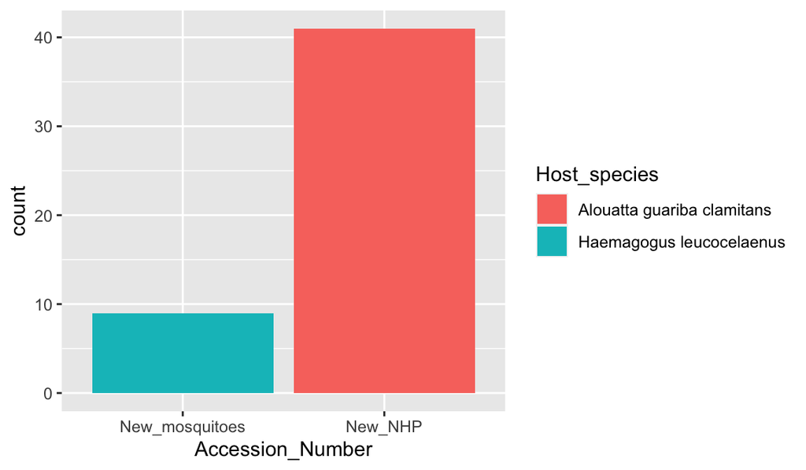

Figure 1: Bar chart showing distribution of cases by species and host type.

```r
horto %>%
  # Determine the count of species for mosquitoes and non-human primates
  group_by(Accession_Number,Host_species) %>%
  summarise(count=n()) %>%
  # Reorder the data in ascending order
  mutate(Accession_Number = reorder(Accession_Number,count, increasing = T)) %>%
  # Create a bar chart using ggplot
  ggplot(aes(x = Accession_Number, count, fill = Host_species)) +
  geom_col(position = "dodge")
```

We can see that among confirmed YFV cases, we have one species of mosquitoes, *Haemagogus leucocelaenus*, and one species of NHP, *Alouatta*.

Let’s now map these cases to understand its spatial distribution in Horto. Have a look again at the dataframe - what information here would be useful for mapping?

## Mapping basics

- Country
- State
- Municipality
- Location: Place where the sample was collected.
- Latitude: part of the coordinate system (Y-axis), exact location north or south of the equator.
- Longitude: part of the coordinate system (X-axis), exact location east or west of prime meridian at Greenwich.

Let’s now create a map showing Sao Paulo municipality, where Horto Florestal is located.

- The package *sf* and *ggspatial* offers spatial feature handling and mapping capabilities.
- *geobr* offers maps of Brazil containing vector data on location, shape, and geographical attributes at various administrative levels.
- In this tutorial we will be extracting municipalities, conservation areas, and census tracts, all using *geobr*.

Let’s start with installing packages for *geobr*, *sf*, and *ggspatial*, then loading the libraries into R. You can do this using the function *install.packages(” “) - give this a go yourself :)

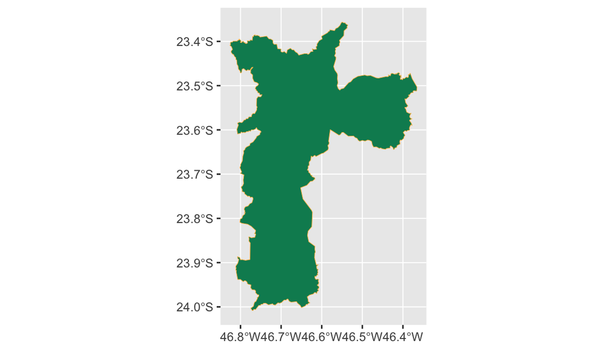

Figure 2: Map of Sao Paulo municipality

```r
library(geobr)
library(sf)
library(ggspatial)

# Extract Sao Paulo municipality
sp_muni <- read_municipality(code_muni = "SP", year = 2020, showProgress = FALSE) %>%
  filter(code_muni == "3550308")

# head() allows us to get an overview of our data. We can see that contains spatial information and it's a MULTIPOLYGON.
head(sp_muni)
## Simple feature collection with 1 feature and 7 fields
## Geometry type: MULTIPOLYGON
## Dimension:     XY
## Bounding box:  xmin: -46.82619 ymin: -24.00826 xmax: -46.36531 ymax: -23.35629
## Geodetic CRS:  SIRGAS 2000
##   code_muni name_muni code_state abbrev_state name_state code_region
## 1   3550308 São Paulo         35           SP  São Paulo           3
##   name_region                           geom
## 1     Sudeste MULTIPOLYGON (((-46.54624 -...
# Simple feature collection with 1 feature and 7 fields
# Geometry type: MULTIPOLYGON
# Dimension:     XY
# Bounding box:  xmin: -46.82619 ymin: -24.00826 xmax: -46.36531 ymax: -23.35629
# Geodetic CRS:  SIRGAS 2000
#   code_muni name_muni code_state abbrev_state name_state code_region name_region
# 1   3550308 São Paulo         35           SP  São Paulo           3     Sudeste
#                             geom
# 1 MULTIPOLYGON (((-46.54624 -...

# Create a map showing Sao Paulo municipality
ggplot() +
  geom_sf(data = sp_muni, fill = "#008A60", colour="#FEBF57", size=2,show.legend = FALSE)
```

Let’s highlight the Horto Florestal area on the map. Because Horto Florestal is a conservation area, we can use **geobr** to extract the shapefile of the park from the function *read_conservation_units()*. We will use the official park name which is “PARQUE ESTADUAL ALBERTO LöFGREN”.

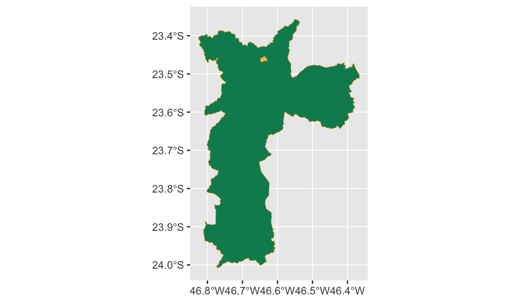

Figure 3: Map of Sao Paulo municipality including the highlighted area of Horto Florestal

```r
# Using geobr, import mapping feature details on all main conservation areas in Brazil
cons_areas <- read_conservation_units(showProgress = FALSE)

# Extract administrative boundary of Horto
horto_shp <- cons_areas %>%
  filter(name_conservation_unit == "PARQUE ESTADUAL ALBERTO LöFGREN")

# Create a map showing the greater metropolitan area of Sao Paulo with Horto Florestal highlighted
ggplot() +
  geom_sf(data = sp_muni, fill = "#008A60", colour="#FEBF57", show.legend = FALSE) +
  geom_sf(data = horto_shp, fill = "#FEBF57", colour="#FEBF57", show.legend = FALSE)
```

Now let’s create a zoomed in version of our map showing Horto and its surrounding neighbourhoods. We will represent its nearby neighbourhoods at the census tracts administrative level using the data from *geobr*.

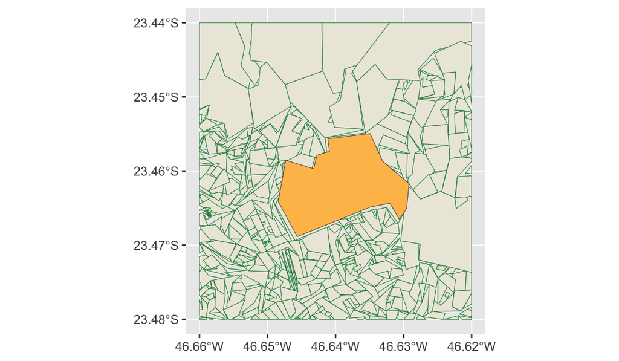

Figure 4: Map of Horto Florestal area in Sao Paulo

```r
# Using geobr, import census tracts for Sao Paulo municipality
census_tracts  <- read_census_tract(code_tract = 3550308, year = 2020, showProgress = FALSE)

# Crop census tract feature so we can zoom into the neighbouring areas containing Horto Florestal
# Using I've indicated the spatial boundaries for our map
cts_crop <- st_crop(census_tracts, ymin = -23.48, ymax = -23.44,
                  xmin = -46.66, xmax = -46.62)
# Map Horto within the SP municipality boundary
ggplot() +
  geom_sf(data = cts_crop, aes(geometry = geom), fill = "#ede9dd", colour = "#238B45", show.legend = FALSE) +
  geom_sf(data = horto_shp, aes(geometry = geom), fill="#FEBF57", size = 10, show.legend = FALSE)
```

## Mapping samples collected from Horto Florestal

Let’s now create a map of Horto showing the locations of confirmed cases from *Haemagogus* using our *Horto* data set. First, we’ll need to convert our data, the data frame, to a spatial feature for mapping. Then, we will run some *sf* functions on our data to ensure our data is in an appropriate format for mapping. We will then use the *subset()* function to extract data on Haemagogus cases only. Finally, we will map those case locations.

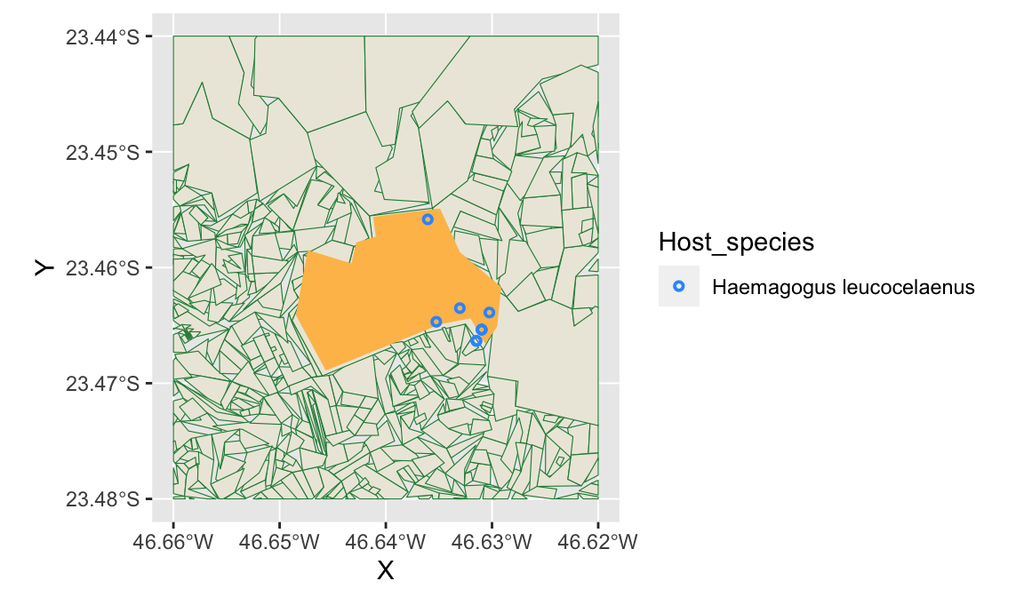

Figure 5: Confirmed YFV cases from Haemagogus in Horto Florestal

```r
# Convert data frame to a spatial feature
horto_data <- st_as_sf(horto, coords = c("longitude","latitude"))

# Ensure it uses the same coordinate system as the SP municipality boundary
st_crs(horto_data) <- st_crs (sp_muni)

# Create a points spatial feature with latitude and longitude coordinates attached
horto_lat_long <- cbind(horto_data, st_coordinates(horto_data))

# Extract data on Haemagogus only
horto_hg <- subset(horto_lat_long, Host_species == "Haemagogus leucocelaenus")

# Create a map showing distribution of Haemagogus. Sample locations of Haemagogus will be indicated using blue points.
ggplot() +
 geom_sf(data = cts_crop, aes(geometry = geom), fill = "#ede9dd", colour = "#238B45", show.legend = FALSE) +
    geom_sf(data = horto_shp, fill = "#FEBF57", colour="#FEBF57", show.legend = FALSE) +
  geom_point (data = horto_hg, aes(x = X, y = Y, colour = Host_species), shape = 1, stroke = 1, size = 1) +
  scale_color_manual(values=c("#3399FF"))
```

Only 9 cases were confirmed for *Haemagogus*. What can you infer about the cases based on its spatial distribution? We can see that some confirmed cases come from samples collected in the same location.

Can you revise the code above and create one for *Alouatta*? You will need to use the *subset* function to create a new data set for *Alouatta* only by extracting the data from *horto_lat_long*.

Below are some hints…

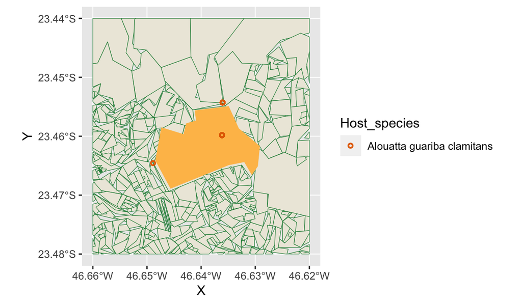

Figure 6: Confirmed YFV cases from Alouatta in Horto Florestal

```r
# Extract data on Alouatta only
horto_alo <- subset(horto_lat_long, Host_species == "Alouatta guariba clamitans")

# Create a map showing distribution of Alouatta
ggplot() +
 geom_sf(data = cts_crop, aes(geometry = geom), fill = "#ede9dd", colour = "#238B45", show.legend = FALSE) +
    geom_sf(data = horto_shp, fill = "#FEBF57", colour="#FEBF57", show.legend = FALSE) +
  geom_point (data = horto_alo, aes(x = X, y = Y, colour = Host_species), shape = 1, stroke = 1, size = 1) +
  scale_color_manual(values=c("#E56D00"))
```

There were 41 confirmed cases for *Alouatta*. What can you infer about the spatial distribution of cases? We can see that cases for *Alouatta* were observed within and at the borders of Horto Florestal.

Let’s now create a map showing both host species.

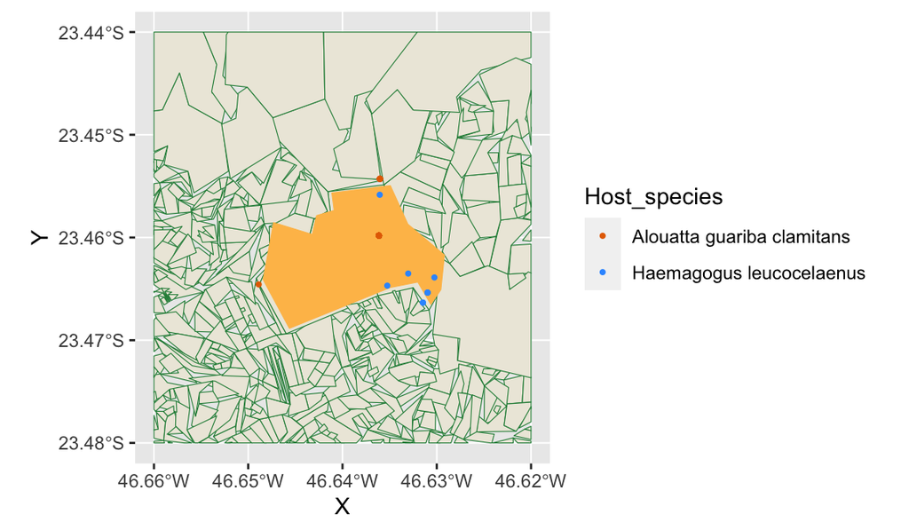

Figure 7: Confirmed YFV cases from Haemagogus and Alouatta in Horto Florestal

Let’s now format our map a bit by adding a **north arrow**, **scale bar**, and remove the grid from our map. We will be using the *ggspatial* package to do this. Click **Zoom** above the figure in RStudio to see the map with updated formatting.

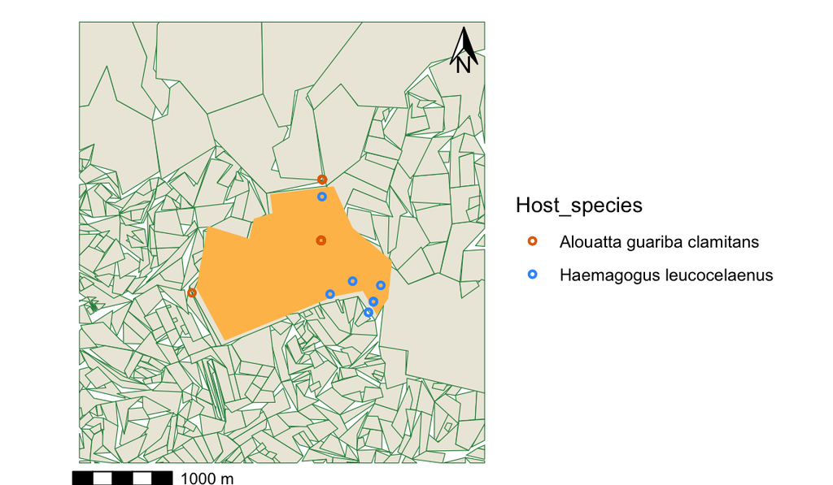

Figure 8: Confirmed YFV cases from Haemagogus and Alouatta in Horto Florestal (with all relevant map labels)

```r
ggplot() +
 geom_sf(data = cts_crop, aes(geometry = geom), fill = "#ede9dd", colour = "#238B45", show.legend = FALSE) +
    geom_sf(data = horto_shp, fill = "#FEBF57", colour="#FEBF57", show.legend = FALSE) +
  geom_point (data = horto_lat_long, aes(x = X, y = Y, colour = Host_species), shape = 1, stroke = 1, size = 1) +
  scale_color_manual(values=c("#E56D00","#3399FF")) +
  # Add scalebar
  annotation_scale(location = "bl", pad_y = unit(-0.005, "cm")) +
  # Add north arrow
  annotation_north_arrow(location = "tr", which_north = "true",
                         pad_x = unit(0.5, "cm"),
                         pad_y = unit(0.5, "cm"),
                         height = unit(0.75, "cm"),
                         width = unit(0.5, "cm")) +
  # Reformat the map
  theme(legend.position="bottom",
        panel.border = element_blank(),
        axis.title.x=element_blank(),
        axis.title.y=element_blank(),
        panel.grid.major = element_blank(),
        panel.grid.minor = element_blank()) +
  theme_void()
```

Since confirmed cases were observed in both 2017 and 2018, let’s visualise case distribution again by year.

We will need to use the package *lubridate* to extract year information from our data. First, ensure this package is installed and loaded in RStudio.

Here we are adding a new line “**facet_wrap(~year)**” into our ggplot code. This line will help create a map for 2017 and 2018.

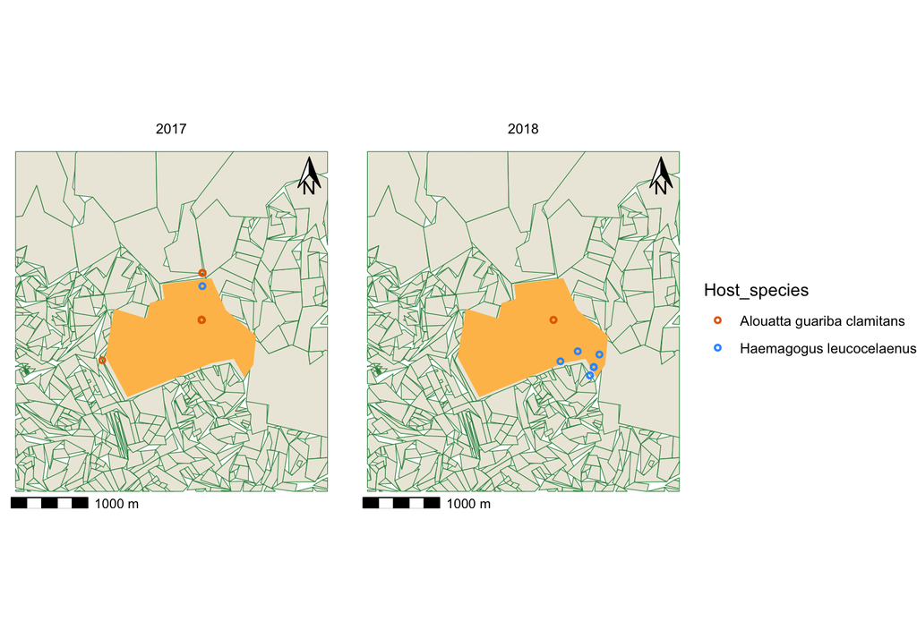

Figure 9: Confirmed YFV cases from Haemagogus and Alouatta in Horto Florestal by year (2017-2018)

```r
library(lubridate)

#convert date in our data column to a date format recognizable by R
horto_lat_long$newdate<-as.Date(horto_lat_long$date, format = "%Y-%m-%d")

#create a new column with year only
horto_lat_long$year <- year(horto_lat_long$newdate)

ggplot() +
 geom_sf(data = cts_crop, aes(geometry = geom), fill = "#ede9dd", colour = "#238B45", show.legend = FALSE) +
    geom_sf(data = horto_shp, fill = "#FEBF57", colour="#FEBF57", show.legend = FALSE) +
  geom_point (data = horto_lat_long, aes(x = X, y = Y, colour = Host_species), shape = 1, stroke = 1, size = 1) +
  scale_color_manual(values=c("#E56D00","#3399FF")) +
  facet_wrap(~year) +
  annotation_scale(location = "bl",
                   pad_y = unit(-0.01, "cm")) + # add scale
  annotation_north_arrow(location = "tr", which_north = "true",
                         pad_x = unit(0.5, "cm"),
                         pad_y = unit(0.5, "cm"),
                         height = unit(0.75, "cm"),
                         width = unit(0.5, "cm")) +
  theme(legend.position="bottom",
        panel.border = element_blank(),
        axis.title.x=element_blank(),
        axis.title.y=element_blank(),
        panel.grid.major = element_blank(),
        panel.grid.minor = element_blank()) +
  theme_void()
```

## Next steps

Can you think of ways that we can improve our map?

- **Environmental data**: Environment and climate change plays a role in determining when and where mosquitoes breed, reside, and feed. We can overlay environmental data such as temperature, precipitation, relative humidity, and elevation, to approximate potential habitat locations of *Haemagogus*. These factors strongly influence the habitats and occurrence of mosquitoes. When mapping, these data sets come in the form of rasters.

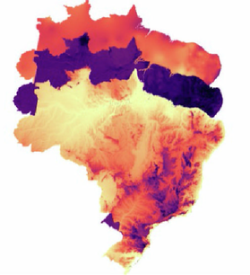

  Rasters data showing environmental conditions

- **Non-human primate reservoirs**: Knowing where non-human primates reside and their movement patterns will enable us to gauge potential reservoir locations. Overlaying this information with mosquito occurrence and NHP observations will allow us to better predict where YFV may emerge.
- **Geospatial modelling**: By integrating spatial information in machine learning models (e.g.species distribution modelling), we can predict the environmental suitability of *Haemagogus* (e.g. probability of seeing mosquito occurrence) across Brazil.

## Additional Readings

Li, S. L., Acosta, A. L., Hill, S. C., Brady, O. J., de Almeida, M. A., Cardoso, J. D. C., … & Messina, J. P. (2022). Mapping environmental suitability of Haemagogus and Sabethes spp. mosquitoes to understand sylvatic transmission risk of yellow fever virus in Brazil. PLoS neglected tropical diseases, 16(1), e0010019. doi:https://doi.org/10.1371/journal.pntd.0010019

Hill, S. C., Dellicour, S., Claro, I. M., Sequeira, P. C., Adelino, T., Thézé, J., … & Faria, N. R. (2022). Climate and land-use shape the spread of zoonotic yellow fever virus. medRxiv, 2022-08. doi: https://doi.org/10.1101/2022.08.25.22278983